# Projeto Integrador: Regressão Linear Múltipla

Luiz Gabriel de Souza

28/06/2021

Este projeto tem como objetivo, atráves de uma regressão multipla, entender a demanda de energia gasta para aquecer prédios (construções de forma geral) como uma função de características dos prédio.

# 1 Analise exploratória

## 1.1 Importação da base de dados e renomeação de colunas

```r
# Pacotes utilizados no projeto
suppressMessages(library(tidyverse))
suppressMessages(library(summarytools))
suppressMessages(library(corrplot))
suppressMessages(library(car))
suppressMessages(library(GGally))
suppressMessages(library(effects))
suppressMessages(library(performance))



# Importação da base de dados
df <- read.table("projeto.csv", header = T, sep = ";", dec = ",")

# Renomeia colunas
df <- df %>%
  rename(
    comp_relat = X1, # Compacidade relativa
    area_super = X2, # Área de superfície
    area_pared = X3, # Área de paredes
    area_cober = X4, # Área de cobertura
    altu_total = X5, # Altura total
    orie_sol   = X6, # Orientação em relação ao sol
    area_envid = X7, # Área de envidraçamento
    dist_area_envid   = X8, # Distribuição da área de envidraçamento
    carga_aquecimento = Y1  # Carga de Aquecimento
  )

# Estrutura dos dados
str(df)
```

```
## 'data.frame':    768 obs. of  9 variables:
##  $ comp_relat       : num  0.98 0.98 0.98 0.98 0.9 0.9 0.9 0.9 0.86 0.86 ...
##  $ area_super       : num  514 514 514 514 564 ...
##  $ area_pared       : num  294 294 294 294 318 ...
##  $ area_cober       : num  110 110 110 110 122 ...
##  $ altu_total       : num  7 7 7 7 7 7 7 7 7 7 ...
##  $ orie_sol         : int  2 3 4 5 2 3 4 5 2 3 ...
##  $ area_envid       : num  0 0 0 0 0 0 0 0 0 0 ...
##  $ dist_area_envid  : int  0 0 0 0 0 0 0 0 0 0 ...
##  $ carga_aquecimento: num  15.6 15.6 15.6 15.6 20.8 ...
```

## 1.2 Estatísticas descritivas da base

```r
summarytools::descr(df)
```

```
## Descriptive Statistics
## df
## N: 768
##
##                     altu_total   area_cober   area_envid   area_pared   area_super
## ----------------- ------------ ------------ ------------ ------------ ------------
##              Mean         5.25       176.60         0.23       318.50       671.71
##           Std.Dev         1.75        45.17         0.13        43.63        88.09
##               Min         3.50       110.25         0.00       245.00       514.50
##                Q1         3.50       134.75         0.10       294.00       600.25
##            Median         5.25       183.75         0.25       318.50       673.75
##                Q3         7.00       220.50         0.40       343.00       747.25
##               Max         7.00       220.50         0.40       416.50       808.50
##               MAD         2.59        54.49         0.22        36.32       108.97
##               IQR         3.50        79.62         0.30        49.00       134.75
##                CV         0.33         0.26         0.57         0.14         0.13
##          Skewness         0.00        -0.16        -0.06         0.53        -0.12
##       SE.Skewness         0.09         0.09         0.09         0.09         0.09
##          Kurtosis        -2.00        -1.78        -1.33         0.10        -1.07
##           N.Valid       768.00       768.00       768.00       768.00       768.00
##         Pct.Valid       100.00       100.00       100.00       100.00       100.00
##
## Table: Table continues below
##
##
##
##                     carga_aquecimento   comp_relat   dist_area_envid   orie_sol
## ----------------- ------------------- ------------ ----------------- ----------
##              Mean               22.31         0.76              2.81       3.50
##           Std.Dev               10.09         0.11              1.55       1.12
##               Min                6.01         0.62              0.00       2.00
##                Q1               12.98         0.68              1.50       2.50
##            Median               18.95         0.75              3.00       3.50
##                Q3               31.68         0.84              4.00       4.50
##               Max               43.10         0.98              5.00       5.00
##               MAD               11.14         0.12              1.48       1.48
##               IQR               18.68         0.15              2.25       1.50
##                CV                0.45         0.14              0.55       0.32
##          Skewness                0.36         0.49             -0.09       0.00
##       SE.Skewness                0.09         0.09              0.09       0.09
##          Kurtosis               -1.25        -0.72             -1.15      -1.36
##           N.Valid              768.00       768.00            768.00     768.00
##         Pct.Valid              100.00       100.00            100.00     100.00
```

É possível observar que estamos trabalhando com uma base de dados que possui 768 registro e que todas elas são númericas, não sendo necessária nenhuma transformação prévia.

# 2 Ajuste e seleção de modelos:Selecionando covariáveis

## 2.1 Análise de correlação da variáveis

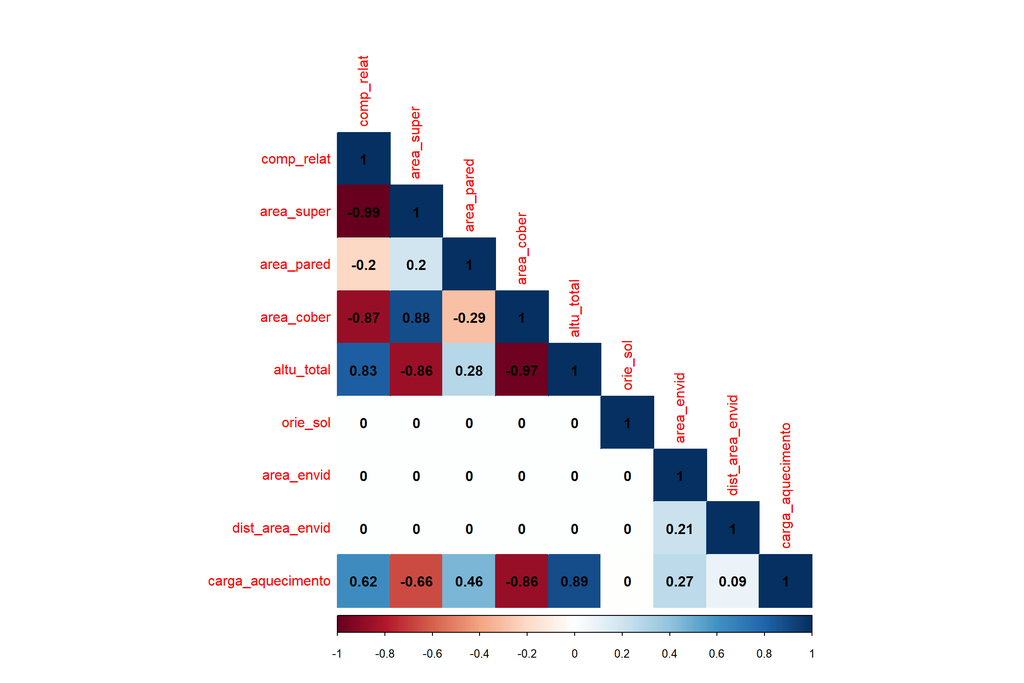

```r
cor <-  cor(df)
corrplot(cor, method="color", type='lower', addCoef.col = "black")
```

É possível observar pela matriz de correlação que as váriveis orien_sol, area_envid e dist_area_envid não possui correlação com as demais variáveis. Por outro lado, comp_relat e area_super possuem alta correlação (positiva e negativa) com quase todas as demais variáveis, exceto a area_pared, o que pode indicar a presença de multicolinearidade. Vou manter todas as variáveis e fazer algumas análises complementares antes de decidir pela exclusão de qualquer variável.

## 2.2 Distribuição das variáveis

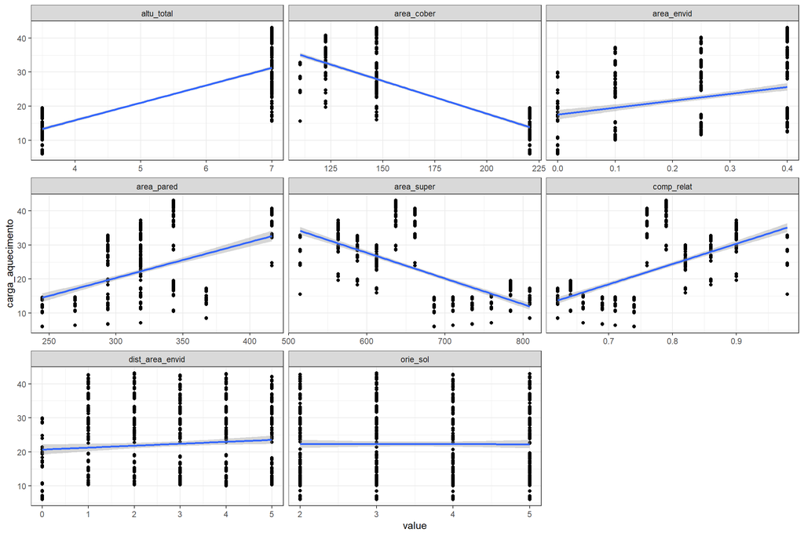

```r
df_long <- df %>%
  pivot_longer(cols = -carga_aquecimento,
               names_to = "variable",
               values_to = "value")

# Plot de cada variável explicativa pela variável de interesse
ggplot(data = df_long,
       mapping = aes(x = value, y = carga_aquecimento)) +
  facet_wrap(facets = ~variable, scale = "free_x") +
  geom_point() +
  geom_smooth(method = "lm")+
  theme_bw()
```

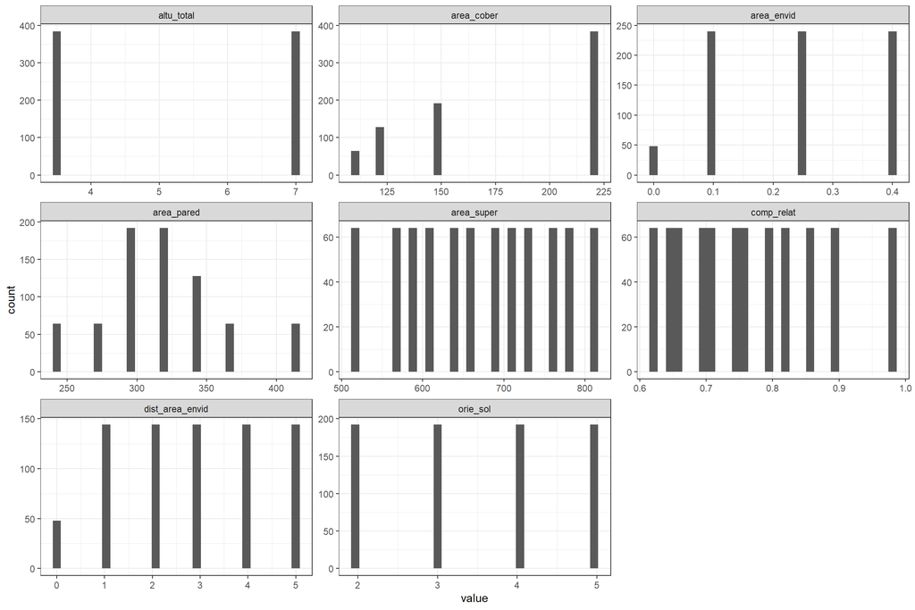

```r
# Histograma de todas as variáveis
df_long %>%
  ggplot(aes(value)) +
  facet_wrap(~ variable, scales = "free") +
  geom_histogram()+
  theme_bw()
```

```r
# Tranformação da variável númerico para categórica
df$orie_sol <- as.factor(df$orie_sol )
```

Por fim, vamos análise se há outliers na variável de interesse:

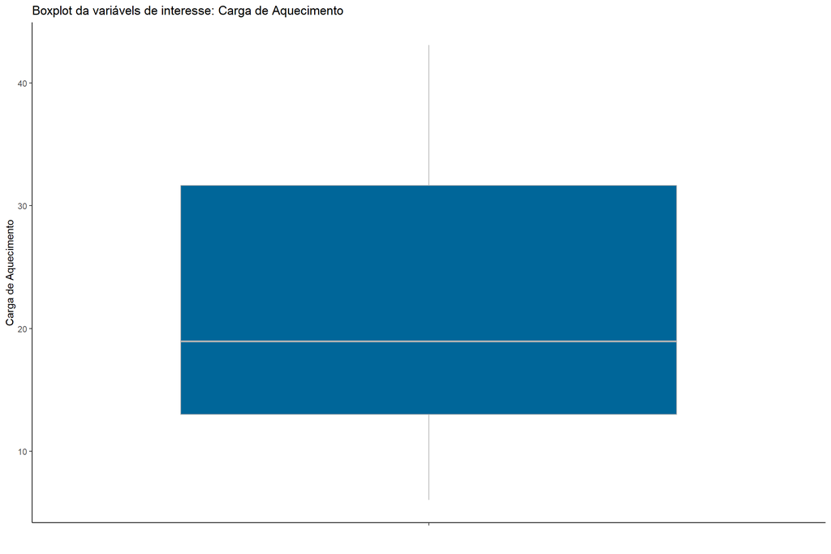

```r
ggplot(df, aes(x=" ", y=carga_aquecimento)) +
  geom_boxplot(fill='#006699', color="grey70")+
  theme_classic()+
  labs(
        x = " ",
        y = "Carga de Aquecimento",
        title = "Boxplot da variávels de interesse: Carga de Aquecimento"
    )
```

Não foi possível encontrar outliers pelo Boxplot.

## 2.3 Fit do modelo para observar a importância das variáveis e análise dos resíduos

```r
m0 <- lm(carga_aquecimento ~
           comp_relat+
           area_super+
           area_pared+
           area_cober+
           altu_total+
           orie_sol+
           area_envid+
           dist_area_envid, data = df)
summary(m0)
```

```
##
## Call:
## lm(formula = carga_aquecimento ~ comp_relat + area_super + area_pared +
##     area_cober + altu_total + orie_sol + area_envid + dist_area_envid,
##     data = df)
##
## Residuals:
##     Min      1Q  Median      3Q     Max
## -9.8997 -1.3353 -0.0137  1.3387  7.6434
##
## Coefficients: (1 not defined because of singularities)
##                   Estimate Std. Error t value Pr(>|t|)
## (Intercept)      83.938537  19.055028   4.405 1.21e-05 ***
## comp_relat      -64.773991  10.302109  -6.287 5.45e-10 ***
## area_super       -0.087290   0.017097  -5.106 4.17e-07 ***
## area_pared        0.060813   0.006656   9.136  < 2e-16 ***
## area_cober              NA         NA      NA       NA
## altu_total        4.169939   0.338406  12.322  < 2e-16 ***
## orie_sol3         0.067812   0.299851   0.226  0.82114
## orie_sol4        -0.052969   0.299851  -0.177  0.85983
## orie_sol5        -0.037500   0.299851  -0.125  0.90051
## area_envid       19.932680   0.814988  24.458  < 2e-16 ***
## dist_area_envid   0.203772   0.070004   2.911  0.00371 **
## ---
## Signif. codes:  0 '***' 0.001 '**' 0.01 '*' 0.05 '.' 0.1 ' ' 1
##
## Residual standard error: 2.938 on 758 degrees of freedom
## Multiple R-squared:  0.9162, Adjusted R-squared:  0.9152
## F-statistic:   921 on 9 and 758 DF,  p-value: < 2.2e-16
```

Vamos estimar os coeficientes novamente, retirando as variáveis *area_cober* e *orie_sol* que não possuem significância estatística.

```r
m1 <- lm(carga_aquecimento ~
           comp_relat+
           area_super+
           area_pared+
           #area_cober+
           altu_total+
           #orie_sol+
           area_envid+
           dist_area_envid, data = df)
summary(m1)
```

```
##
## Call:
## lm(formula = carga_aquecimento ~ comp_relat + area_super + area_pared +
##     altu_total + area_envid + dist_area_envid, data = df)
##
## Residuals:
##     Min      1Q  Median      3Q     Max
## -9.9315 -1.3189 -0.0263  1.3586  7.7169
##
## Coefficients:
##                   Estimate Std. Error t value Pr(>|t|)
## (Intercept)      83.932873  19.018972   4.413 1.17e-05 ***
## comp_relat      -64.773991  10.283093  -6.299 5.06e-10 ***
## area_super       -0.087290   0.017065  -5.115 3.97e-07 ***
## area_pared        0.060813   0.006644   9.153  < 2e-16 ***
## altu_total        4.169939   0.337781  12.345  < 2e-16 ***
## area_envid       19.932680   0.813483  24.503  < 2e-16 ***
## dist_area_envid   0.203772   0.069875   2.916  0.00365 **
## ---
## Signif. codes:  0 '***' 0.001 '**' 0.01 '*' 0.05 '.' 0.1 ' ' 1
##
## Residual standard error: 2.933 on 761 degrees of freedom
## Multiple R-squared:  0.9162, Adjusted R-squared:  0.9155
## F-statistic:  1387 on 6 and 761 DF,  p-value: < 2.2e-16
```

Com a retirada de duas variáveis, o novo modelo teve uma pequena melhora no $R^{2}$ ajustado. No entanto apresenta baixa significância para a variável *dist_area_envid*. Vou retira-la também e realizar a análise novamente.

```r
m2 <- lm(carga_aquecimento ~
           comp_relat+
           area_super+
           area_pared+
           #area_cober+
           altu_total+
           #orie_sol+
           area_envid
           #dist_area_envid+
           , data = df)
summary(m2)
```

```
##
## Call:
## lm(formula = carga_aquecimento ~ comp_relat + area_super + area_pared +
##     altu_total + area_envid, data = df)
##
## Residuals:
##      Min       1Q   Median       3Q      Max
## -10.3862  -1.3667  -0.0142   1.3161   7.5555
##
## Coefficients:
##               Estimate Std. Error t value Pr(>|t|)
## (Intercept)  84.387570  19.111753   4.415 1.15e-05 ***
## comp_relat  -64.773991  10.333605  -6.268 6.11e-10 ***
## area_super   -0.087290   0.017149  -5.090 4.51e-07 ***
## area_pared    0.060813   0.006676   9.109  < 2e-16 ***
## altu_total    4.169939   0.339441  12.285  < 2e-16 ***
## area_envid   20.437899   0.798726  25.588  < 2e-16 ***
## ---
## Signif. codes:  0 '***' 0.001 '**' 0.01 '*' 0.05 '.' 0.1 ' ' 1
##
## Residual standard error: 2.947 on 762 degrees of freedom
## Multiple R-squared:  0.9153, Adjusted R-squared:  0.9147
## F-statistic:  1646 on 5 and 762 DF,  p-value: < 2.2e-16
```

Observa-se uma diminuição da mediana dos resíduo, demonstrando melhora na simetria dos acertos. O $R^{2}$ teve baixa variação, o que indica que podemos seguir com este modelo para uma análise mais detalhada dos resíduos.

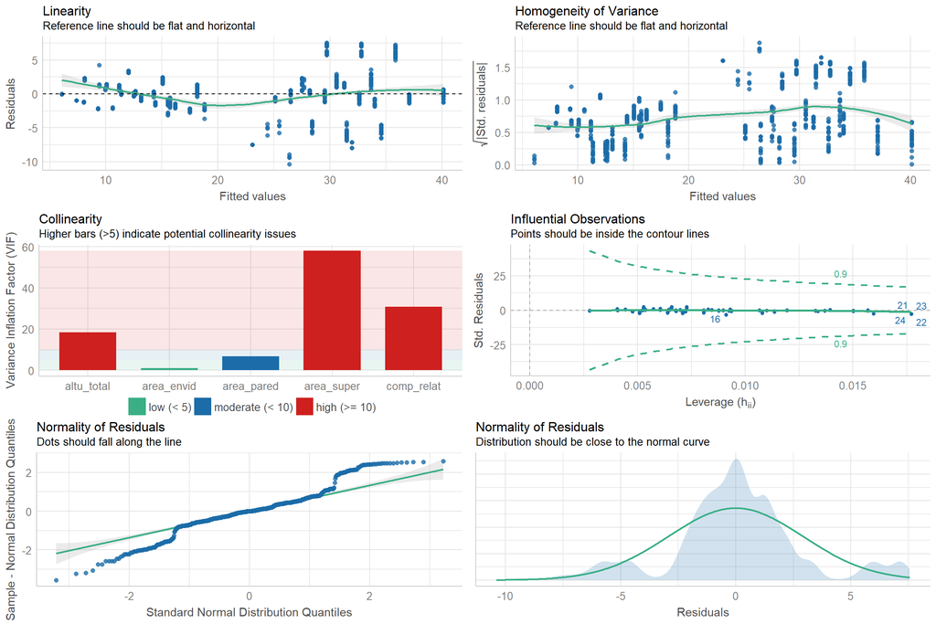

```r
check_model(m2)
```

Observando o gráfico de Colinearidade, temos a análise da inflação da variância, que indica a presença ou não de multicolinearidade. As variáveis *comp_relat* e *area_super* estão acima do valor aceitável, o que é indicativo de inflação da variância, ou em outras palavras, multicolinearidade. Outra sinal de multicolineridade das variáveis é o erro padrão dos parâmetros estimados. É possível observar que tanto para o intercepto quanto para a variável *comp_relat*, apresentam erros elevados, quando comparados com os demais.

Vamos remover a variável *area_super*, que possui o maior VIF, para ver como o modelo responde:

```r
m3 <- lm(carga_aquecimento ~
           comp_relat+
           #area_super+
           area_pared+
           #area_cober+
           altu_total+
           #orie_sol+
           area_envid
           #dist_area_envid+
           , data = df)
summary(m3)
```

```
##
## Call:
## lm(formula = carga_aquecimento ~ comp_relat + area_pared + altu_total +
##     area_envid, data = df)
##
## Residuals:
##      Min       1Q   Median       3Q      Max
## -10.5375  -1.4031   0.1661   1.5154   7.4058
##
## Coefficients:
##               Estimate Std. Error t value Pr(>|t|)
## (Intercept) -11.953019   2.695638  -4.434 1.06e-05 ***
## comp_relat  -14.532441   3.109064  -4.674 3.49e-06 ***
## area_pared    0.034976   0.004407   7.936 7.45e-15 ***
## altu_total    5.606753   0.191580  29.266  < 2e-16 ***
## area_envid   20.437899   0.811660  25.180  < 2e-16 ***
## ---
## Signif. codes:  0 '***' 0.001 '**' 0.01 '*' 0.05 '.' 0.1 ' ' 1
##
## Residual standard error: 2.995 on 763 degrees of freedom
## Multiple R-squared:  0.9124, Adjusted R-squared:  0.9119
## F-statistic:  1986 on 4 and 763 DF,  p-value: < 2.2e-16
```

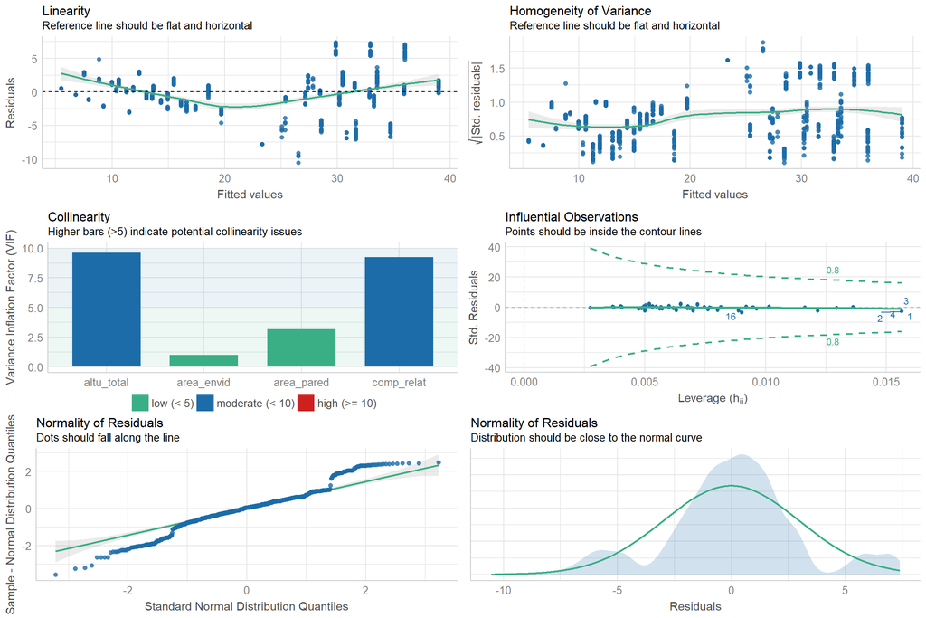

```r
check_model(m3)
```

Observando os gráficos de análise de resíduos, nos chama a atenção o *Normal Q-Q*, que representa a suposição de normalidade dos resíduos. Parece haver alguns registros nas caudas fora da normalidade. Podemos então verificar a presença ou não de normalidade dos resíduos para cada variável explicativa, a fim de entender se temos alguma variável impactando demais na normalidade dos erros.

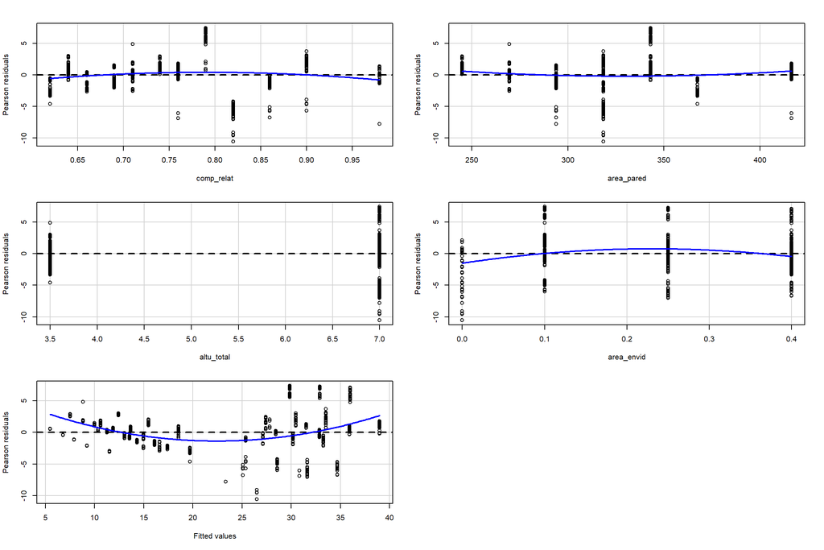

```
##            Test stat Pr(>|Test stat|)
## comp_relat   -6.4668        1.787e-10 ***
## area_pared    2.6544         0.008111 **
## altu_total   -2.6450         0.008337 **
## area_envid   -5.8623        6.796e-09 ***
## Tukey test    9.7757        < 2.2e-16 ***
## ---
## Signif. codes:  0 '***' 0.001 '**' 0.01 '*' 0.05 '.' 0.1 ' ' 1
```

```r
# Multicolinearidade.
car::residualPlots(m3)
```

Outro teste interessante é o de fator de influência de cada variável. Podemos observar nos gráficos abaixo que a pela distância de Cook e dos resíduos normalizados, que algumas variáveis se sobressaem, o que podem indicar que possuem um impacto desproporcional na regressão. Vamos análisar o valor de *dffit* também para podermos selecionar algumas observações da tabela para retirar e testar novamente a regressão.

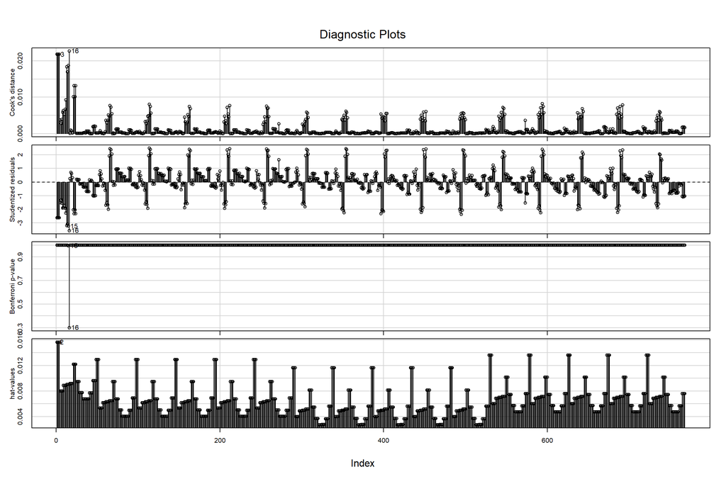

```r
#car::influencePlot(m3)
car::influenceIndexPlot(m3)
```

```r
im <- influence.measures(m3)
summary(im)
```

```
## Potentially influential observations of
##   lm(formula = carga_aquecimento ~ comp_relat + area_pared + altu_total +      area_envid, data = df) :
##
##     dfb.1_ dfb.cmp_ dfb.ar_p dfb.alt_ dfb.ar_n dffit   cov.r   cook.d hat
## 1    0.20  -0.24    -0.14     0.18     0.17    -0.33_*  0.98_*  0.02   0.02
## 2    0.20  -0.24    -0.14     0.18     0.17    -0.33_*  0.98_*  0.02   0.02
## 3    0.20  -0.24    -0.14     0.18     0.17    -0.33_*  0.98_*  0.02   0.02
## 4    0.20  -0.24    -0.14     0.18     0.17    -0.33_*  0.98_*  0.02   0.02
## 13  -0.16   0.15     0.14    -0.18     0.20    -0.30_*  0.95_*  0.02   0.01
## 14  -0.15   0.15     0.14    -0.18     0.20    -0.29_*  0.96_*  0.02   0.01
## 15  -0.16   0.15     0.14    -0.19     0.21    -0.31_*  0.95_*  0.02   0.01
## 16  -0.18   0.17     0.16    -0.21     0.23    -0.34_*  0.94_*  0.02   0.01
## 22   0.06  -0.02    -0.11     0.00     0.15    -0.26_*  0.98    0.01   0.01
## 24   0.06  -0.02    -0.11     0.00     0.15    -0.26_*  0.98    0.01   0.01
## 66   0.11  -0.12    -0.08     0.14    -0.09     0.20    0.97_*  0.01   0.01
```

[output cut: 36 more lines]

Vou eliminar os top 5 registro com maiores *dffit* (que inclui alguns registros que é possível observar nos gráficos de distânciad e cook e dos resíduos normalizados), ou seja, que aprensentam influência significativa na regressão e rodar novamente para ver se temos alguma melhora no modelo.

```r
m4 <- lm(carga_aquecimento ~
           comp_relat+
           #area_super+
           area_pared+
           #area_cober+
           altu_total+
           #orie_sol+
           area_envid
           #dist_area_envid+
           , data = df[-c(1,2,3,4,16),])
summary(m4)
```

```
##
## Call:
## lm(formula = carga_aquecimento ~ comp_relat + area_pared + altu_total +
##     area_envid, data = df[-c(1, 2, 3, 4, 16), ])
##
## Residuals:
##     Min      1Q  Median      3Q     Max
## -9.7551 -1.4614  0.0714  1.4131  7.3236
##
## Coefficients:
##              Estimate Std. Error t value Pr(>|t|)
## (Intercept) -13.72379    2.66430  -5.151 3.31e-07 ***
## comp_relat  -11.96594    3.08772  -3.875 0.000116 ***
## area_pared    0.03692    0.00433   8.525  < 2e-16 ***
## altu_total    5.49765    0.18912  29.069  < 2e-16 ***
## area_envid   19.67913    0.80027  24.591  < 2e-16 ***
## ---
## Signif. codes:  0 '***' 0.001 '**' 0.01 '*' 0.05 '.' 0.1 ' ' 1
##
## Residual standard error: 2.922 on 758 degrees of freedom
## Multiple R-squared:  0.9169, Adjusted R-squared:  0.9165
## F-statistic:  2091 on 4 and 758 DF,  p-value: < 2.2e-16
```

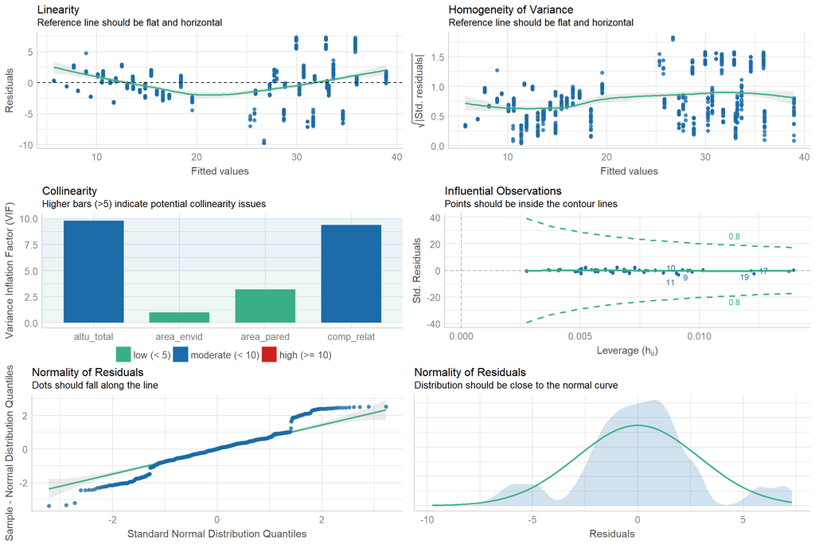

```r
check_model(m4)
```

É possível observar uma pequena melhora na mediana dos resíduos, no erro padrão dos estimadores e no $R^{2}$, mantendo a significância de todos os parâmetros ajustados. Por isso, vamos seguir com o modelo *m4*.

# 3 Diagnóstico do modelo

- **Normalidade (shapiro-wilk)**

```r
res_m4 <- m4$residuals

shapiro.test(res_m4)
```

```
##
##  Shapiro-Wilk normality test
##
## data:  res_m4
## W = 0.95961, p-value = 1.192e-13
```

Verificando os resíduos de modelo, utilizando a o teste de Shapiro-Wilk, rejeitamos a hipótese nula de que há normalidade na amostra. Isso pode acontecer por termos poucas variáveis no modelo e que talvez outras variáveis não captadas possam contribuir para a normalidade.

- **Independência**

Assumimos como pressuposto que os dados foram coletados independentemente.

- **Homogeneidade/Heretocedasticidade (Breush-Pagan)** Vamos validar se a variância dos resíduos são constantes.

```r
ncvTest(m4)
```

```
## Non-constant Variance Score Test
## Variance formula: ~ fitted.values
## Chisquare = 161.2274, Df = 1, p = < 2.22e-16
```

Devido ao p-valor baixo, o teste indica que não podemos assumir a hipótese nula que de a variância dos resíduos são constantes. Da mesma forma que o teste de normalidade, isso pode acontecer por termos poucas variáveis no modelo e que talvez outras variáveis não captadas possam contribuir para a variância constante dos resíduos.

# 4 Interpretação dos componentes do modelo

O ajuste da regressão nos indica seguinte função que generaliza o modelo:

$$y = -13.7237+comp\_relat*-11.9659 + area\_pared*0.0369 + altu\_total*5.4976 + area\_envid*19.6791$$
É possível observar que a *Compacidade Relativa* possui relação negativa com a carga de aquecimento. A compacidade relativa determina o “mede a relação entre as paredes da fachada do edifício e sua superfície, definindo uma relação percentual com o perímetro de um círculo de igual área e o perímetro das paredes exteriores.” (Marcos, 2019) Dessa forma, faz sentido que quanto maior o índice, menor é a necessidade de carga de aquecimento.

Para a variável *Área de Paredes*, possui impacto postivo sobre a demanda de carga de aquecimento, uma vez que quando maior a área, maior a necessidade de aqucimento. No entanto, o impacto por mais que seja signicante, possui um parâmetro de valor baixo.

Para a *Altura Total*, o impacto é positivo, uma vez que quando maior a altura do edificio, maior a necessidade de carga de aquecimento.

Por fim, a *Área de Envidraçamento* impacta positivamente no modelo, pois quanto maior a área de envidraçãmento, maior é a necessidade de demanda de carga de aquecimento, uma vez que o vidro não mantém a temperatura do ambiente tão bem quanto outros materiais mais eficiêntes nesse sentido.

Todos os parâmetros possuem baixa erro padrão e signifância estatística.

# 5 Avaliação do ajuste geral do modelo.

O modelo se comparta bem, pois tem um $R^{2}$ de *91%* que garante a explicabilidade do modelo. Além disso, foram realizados ajustes finos que impactaram: - Diminuição os impactos da multicolinearidade; - Diminuição do impacto de observações com forte influência sobre os resíduos; - Garantia da significância estatística dos parâmetros; - Diminuição dos erros padrão dos estimadores; - Diminuição dos da mediana dos resíduos.

No entanto, algumas métricas ainda precisam ser melhoradas, talvez com algumas tranformações dos dados ou com a inclusão de mais variáveis explicativas. Algumas dessa métricas são:

- AIC e BIC: Apesar e uma molhora desses indicares quando comparamos m0 e m4, acretido que eles podem ser otimizadas para diminuirem a complexidade do modelo, via processo de stepwise.

```r
AIC_m0 <- AIC(m0)
BIC_m0 <- BIC(m0)
AIC_m4 <- AIC(m4)
BIC_m4 <- BIC(m4)

AIC <- data.frame(AIC_m0,AIC_m4)
BIC <- data.frame(BIC_m0,BIC_m4)

knitr::kable(list(BIC,AIC))
```

| BIC_m0 | BIC_m4 |
| --- | --- |
| 3897.86 | 3836.147 |

| AIC_m0 | AIC_m4 |
| --- | --- |
| 3846.779 | 3808.324 |

```r
MSE_m0 <- data.frame(m0 = mean(m0$residuals^2))
MSE_m4 <- data.frame(m4 = mean(m4$residuals^2))
knitr::kable(list(MSE_m0, MSE_m4), align = 'c')
```

| m0 |
| --- |
| 8.519039 |

| m4 |
| --- |
| 8.479447 |

# 6 Predict do modelo

Abaixo apresente 3 configurações de predios e calculo as predições da carga de aquecimento necessária para cada edíficio.

```r
teste <- data.frame(comp_relat = c(0.7,0.8,0.9),
                    area_pared = c(285,270,290),
                    altu_total = c(7,3.5,7),
                    area_envid = c(0.1,0,0.1))
predict(m4, teste)
```

```
##         1         2         3
## 28.872243  5.912253 26.663628
```

Os ajustes me parecem fazer sentido, dado a combinação dos de cada um dos exemplos. As variáveis *altu_total* e *area_envid*, por exemplo, são menores para a segunda observação, o que indica uma necessidade menor de carga de aquecimento, o que de fato é expressa nos dados.

Abaixo, apresento também o intervalo de confiança e o de predição das amostras criadas.

- Intervalo de Confiança:

```r
predict(m4, newdata = teste, se.fit = TRUE, interval = c("confidence"))
```

```
## $fit
##         fit       lwr       upr
## 1 28.872243 27.572300 30.172185
## 2  5.912253  5.198468  6.626038
## 3 26.663628 26.243779 27.083478
##
## $se.fit
##         1         2         3
## 0.6621893 0.3636012 0.2138709
##
## $df
## [1] 758
##
## $residual.scale
## [1] 2.921537
```

- Intervalo de Predição:

```r
predict(m4, newdata = teste, se.fit = TRUE, interval = c("prediction"))
```

```
## $fit
##         fit        lwr      upr
## 1 28.872243 22.9915007 34.75298
## 2  5.912253  0.1327409 11.69177
## 3 26.663628 20.9130158 32.41424
##
## $se.fit
##         1         2         3
## 0.6621893 0.3636012 0.2138709
##
## $df
## [1] 758
##
## $residual.scale
## [1] 2.921537
```

O intervalo de confiança, ao nível de 95%, parece bem rezoavel na predição das amostras, com uma distância média muito próxima do erro. No intervalo de predição, apesar da expanção do intervalo, a predição também tem um bom desempenho.

# 7 Conclusão

Por fim, o modelo proposto possui utilidade e acredito que poderia ser utilizado para recomendações de carga de aquecimento de novos edificios. Os ajustes realizaddos garantiram uma explicabilidade da variável de interesse com um nível significativo. Existem algumas melhorias que ainda podem ser feitas, conforme citadas acima, que podem melhorar ainda mais a performance do modelo.

Gostaria de deixar registado que este projeto me ajudou muito a comprender melhor o processo de ajuste de um modelo de regressão. Pude aplicar diversos conceitos estatísticos vistos em aula e entender melhor o grau de complexidade na composição de um modelo completo.

# 8 Referências

- Thieme, C. Understanding Linear Regression Output in R. [link](https://towardsdatascience.com/understanding-linear-regression-output-in-r-7a9cbda948b3). Acessado em 14/07/2021.
- Yihui Xie, J. J. Allaire, Garrett Grolemund. R Markdown: The Definitive Guide. [link](https://bookdown.org/yihui/rmarkdown/html-document.html#table-of-contents).
- A. Kassambara. [link](http://www.sthda.com/english/)
- Marcos. Arquitetura Economica: Indice de Compacidade.[link](https://arquiteturam.wixsite.com/arqm/post/arquitetura-econ%C3%B4mica-%C3%ADndice-de-compacida)de. Acessado em 14/07/2021